# Allatostatin-C-like Receptor Analysis

Kilicali Isildayancan

2023-04-17

# A0A891XI80

## First Domain

### Homologies

Psi-blast search against Swiss-Prot:

#### First 5 Full Homologues

```
##                                     Receptor Name              Organism
## 1 C-X-C chemokine receptor type 3-2 [Danio rerio]           Danio rerio
## 2                 C-X-C chemokine receptor type 3            Bos taurus
## 3                 C-X-C chemokine receptor type 3          Capra hircus
## 4                 C-X-C chemokine receptor type 1 Oryctolagus cuniculus
## 5                 C-X-C chemokine receptor type 5     Rattus norvegicus
##   Percent Identity Query Cover E value
## 1            64.58         99%  3e-133
## 2            41.18        100%   4e-61
## 3            40.83        100%   8e-61
## 4            39.86         95%   2e-57
## 5            36.11         98%   3e-56
```

Best homologue is from Danio Rerio, with UniProt ID: E9QJ73

#### First 50 Unique Homologues

```
##  [1] "C-X-C chemokine receptor type 3-2 [Danio rerio]"
##  [2] "C-X-C chemokine receptor type 3"
##  [3] "C-X-C chemokine receptor type 1"
##  [4] "C-X-C chemokine receptor type 5"
##  [5] "C-X-C chemokine receptor type 2"
##  [6] "C-X-C chemokine receptor type 4-B"
##  [7] "C-C chemokine receptor type 4"
##  [8] "C-X-C chemokine receptor type 4"
##  [9] "C-X-C chemokine receptor type 4-A"
## [10] "Atypical chemokine receptor 4"
## [11] "C-C chemokine receptor type 6"
## [12] "C-C chemokine receptor type 9"
## [13] "C-C chemokine receptor type 2"
## [14] "Probable C-C chemokine receptor type 3"
## [15] "Type-1 angiotensin II receptor B"
```

The similarity of the 50th match: 32.27s

### Motifs

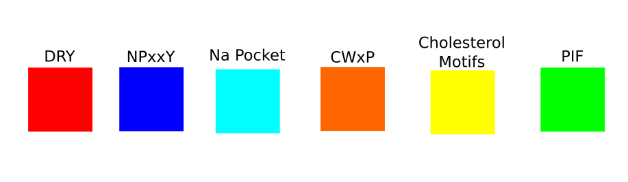

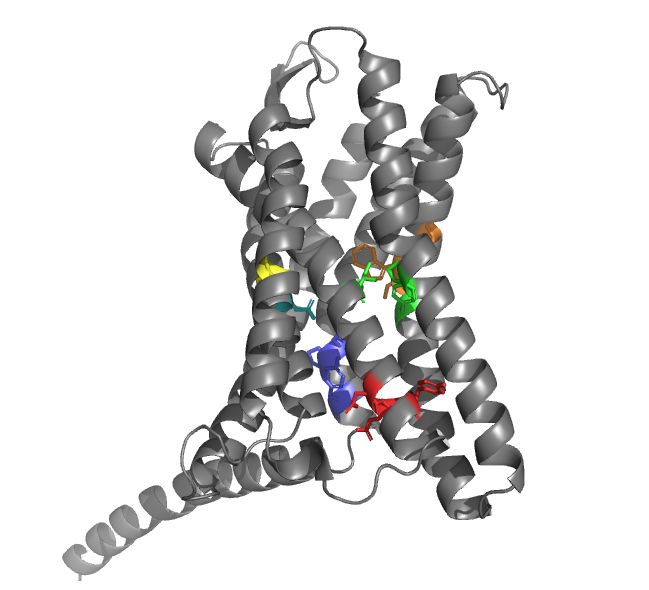

### Conservation

Conservation of the protein from SwissProt with highest homology to the first domain: CXC chemokine receptor type 3-2, UniProt ID: E9QJ73

#### Conservation in the homolog

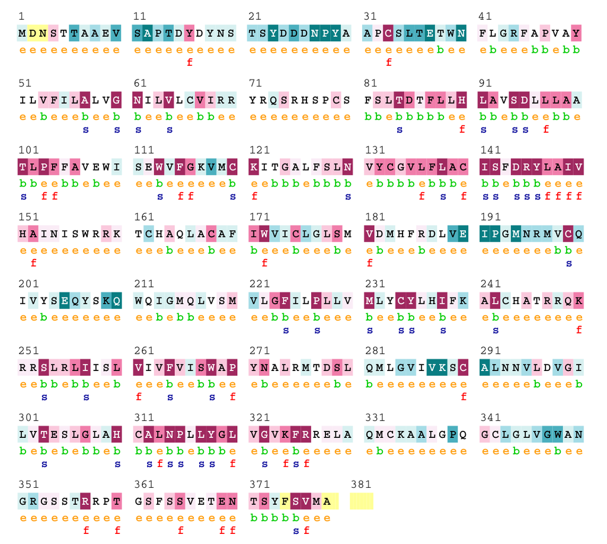

#### Pairwise alignment with homolog

Looking at the conserved sites predicted by ConSurf, and cross-referencing to our first domain sequence:

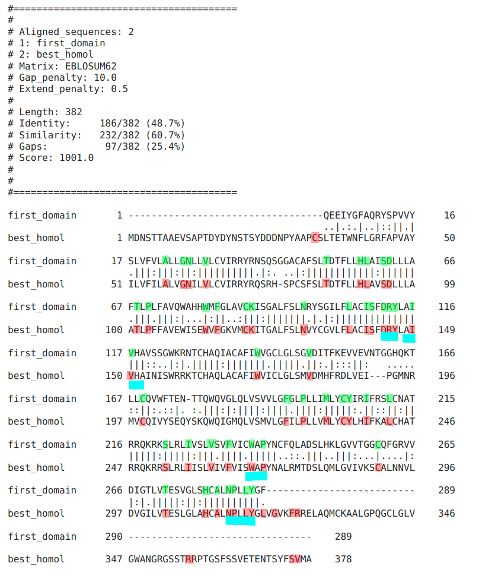

#### Superimposition

RMSD: 0.843

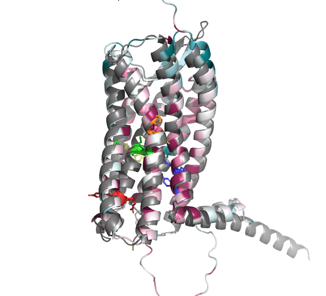

* Both are AlphaFold predicted structures

## Second domain

### Homologies

Psi-blast search against Swiss-Prot:

#### First 5 Full Homologues

```
##                     Receptor Name              Organism Percent Identity
## 1 C-X-C chemokine receptor type 3            Bos taurus            43.94
## 2 C-X-C chemokine receptor type 3          Capra hircus            43.25
## 3 C-X-C chemokine receptor type 1 Oryctolagus cuniculus            37.41
## 4 C-X-C chemokine receptor type 1        Macaca mulatta            37.04
## 5 C-X-C chemokine receptor type 2     Rattus norvegicus            37.76
##   Query Cover E value
## 1         96%   9e-66
## 2         96%   4e-65
## 3         95%   1e-61
## 4         99%   8e-59
## 5         95%   2e-58
```

Best homologue is from Bos taurus, with UniProt ID: Q5MD61

#### First 50 Unique Homologues

```
## [1] "C-X-C chemokine receptor type 3"
## [2] "C-X-C chemokine receptor type 1"
## [3] "C-X-C chemokine receptor type 2"
## [4] "C-X-C chemokine receptor type 4-B"
## [5] "C-X-C chemokine receptor type 5"
## [6] "C-X-C chemokine receptor type 4"
## [7] "C-X-C chemokine receptor type 4-A"
## [8] "C-C chemokine receptor type 2"
## [9] "C-X-C chemokine receptor type 3-2 [Danio rerio]"
```

The similarity of the 50th match: 31.03

### Motifs

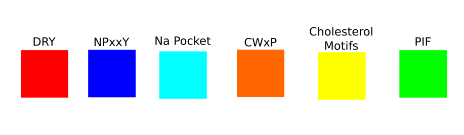

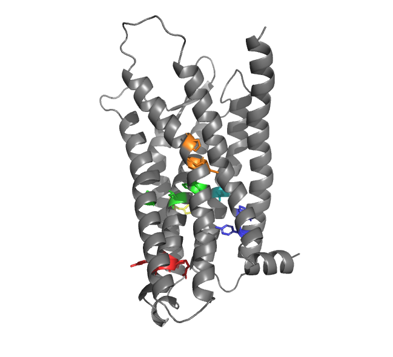

### Conservation

Conservation of the protein from SwissProt with highest homology to the second domain: CXC chemokine receptor type 3, UniProt ID: Q5MD61

#### Pairwise alignment with homolog

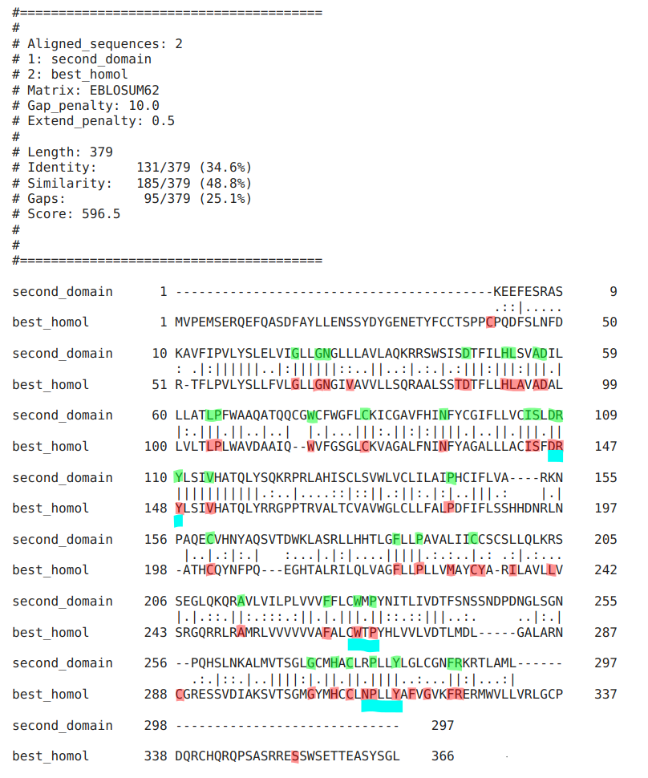

#### Superimposition

RMSD: 1.194

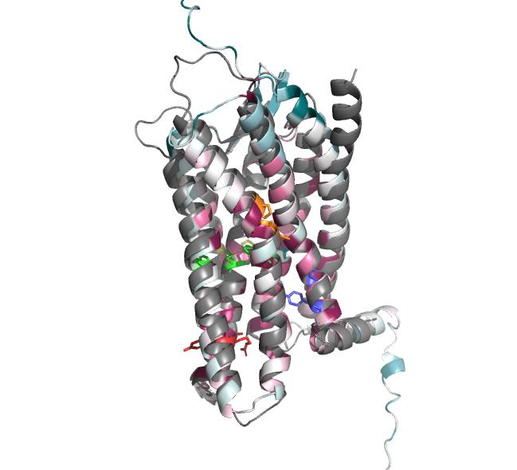

## Relative domains

### Sequences

N-terminal domain [1-34]: MDQGLSTTEDYWDYDYETYSLSPGMSESHAAPCL

First domain [35-323]: QEEIYGFAQRYSPVVYSLVFVLALLGNLLVLCVIRRYRNSQSGGACAFSLTDTFLLHLAI…

Linker domain [324-400]: VGVKFRRELVKMCKGLLGRRGLLGMEEWRERRIRRTTASFSSAESEHTSYSVMMRMDVELDGLFRQNGTYDYDEYEY

Second domain [401-697]: KEEFESRASKAVFIPVLYSLELVIGLLGNGLLLAVLAQKRRSWSISDTFILHLSVADILL…

C-terminal domain [697-861]: KRTTVESESSLWELGVGEEAPPDQNPEEEELRTITSVDHQVQSNSNGVGGISRLGPNGASPAGTNRFHFSRCLKLAAQRPQDVQELTPELHTHKGIQDGIEAAVEVTDGGAEKENHHHSHNDLKSFLLLEALGATPQPPQDAGKDPVWDREEQGEEPHYQAADL

#### Note: Linker sequence aligns to the c-terminal (non-membrane) domain of a chemokine receptor from Danio rerio, which was the best homologue that aligned to the first domain. The “linker” could be the continuation of the first domain, and the linker might be absent in this case.

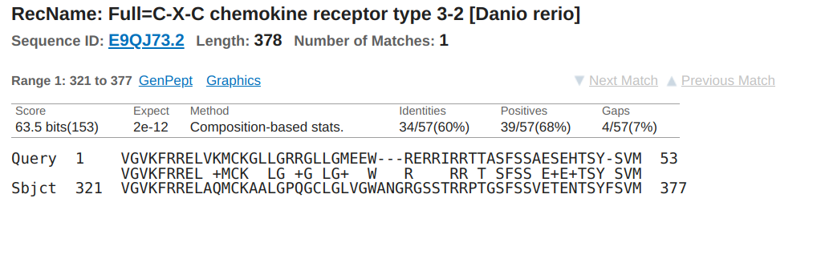

### Pairwise alignment of relative domains

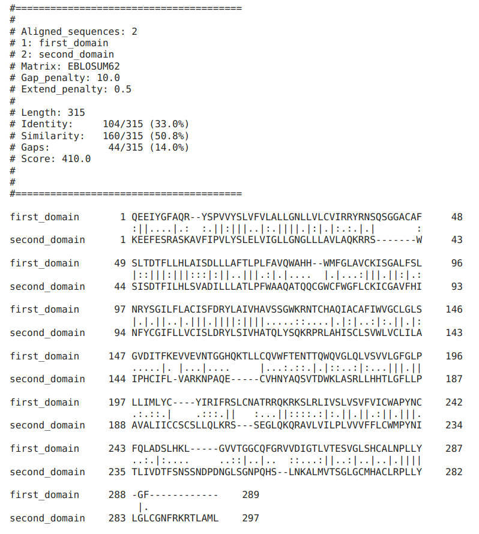

### Pairwise alignment of linker to the full sequence

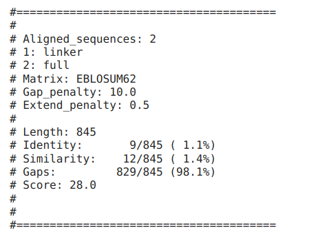

## Genomic sequence

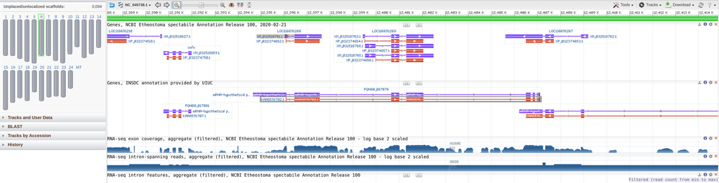

#### Single splice variants

##### First domain single GPCR:

MDQGLSTTEDYWDYDYETYSLSPGMSESHAAPCLQEEIYGFAQRYSPVVYSLVFVLALLGNLLVLCVIRR YRNSQSGGACAFSLTDTFLLHLAISDLLLAFTLPLFAVQWAHHWMFGLAVCKISGALFSLNRYSGILFLA CISFDRYLAIVHAVSSGWKRNTCHAQIACAFIWVGCLGLSGVDITFKEVVEVNTGGHQKTLLCQVWFTEN TTQWQVGLQLVSVVLGFGLPLLIMLYCYIRIFRSLCNATRRQKRKSLRLIVSLVSVFVICWAPYNCFQLA DSLHKLGVVTGGCQFGRVVDIGTLVTESVGLSHCALNPLLYGFVGVKFRRELVKMCKGLLGRRGLLGMEE WRERRIRRTTASFSSAESEHTSYSVMV

##### Second domain single GPCR:

MMRMDVELDGLFRQNGTYDYDEYEYKEEFESRASKAVFIPVLYSLELVIGLLGNGLLLAVLAQKRRSWSI SDTFILHLSVADILLLATLPFWAAQATQQCGWCFWGFLCKICGAVFHINFYCGIFLLVCISLDRYLSIVH ATQLYSQKRPRLAHISCLSVWLVCLILAIPHCIFLVARKNPAQECVHNYAQSVTDWKLASRLLHHTLGFL LPAVALIICCSCSLLQLKRSSEGLQKQRAVLVILPLVVVFFLCWMPYNITLIVDTFSNSSNDPDNGLSGN PQHSLNKALMVTSGLGCMHACLRPLLYLGLCGNFRKRTLAMLKRTTVESESSLWELGVGEEAPPDQNPEE EELRTITSVDHQVQSSQC